# EXPORTS North Atlantic (PAP) Epoch 1 vs Epoch 3 Comparison

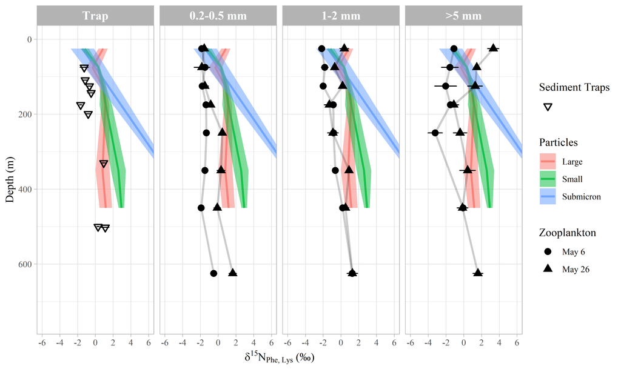

```r
## Plotting Phe and Lys
plot.parts_zoops.SAAC =
  ggplot(data = Data.plots.avg.parts[!is.na(Data.plots.avg.parts$SAA),],
         aes(x = SAAC, y = Depth, xmin = SAAC-SDSAAC, xmax = SAAC+SDSAAC, color = Sizecat, group = Sizecat))+
  scale_y_reverse() +
  geom_path(size = 1, alpha=0.8)+
  geom_ribbon(aes(fill = Sizecat), alpha = 0.50, color = NA)+labs(fill = "Particles")+
  geom_errorbarh(data = Data.plots.zoops,
                 aes(x = SAAC, xmin = SAAC-SDSAAC, xmax = SAAC+SDSAAC), height = 1, size = 0.5, linetype = 1, color = 'black')+
  geom_point(data = Data.plots.zoops,
             aes(x = SAAC, y = Depth, xmin = SAAC-SDSAAC, xmax = SAAC+SDSAAC, shape = Epoch),
             color = "black", fill="black", stroke = 0.5, size=3)+
  geom_path(data = Data.plots.zoops,
            aes(x = SAAC, xmin = SAAC-SDSAAC, xmax = SAAC+SDSAAC, y = Depth, group = interaction(Location,Epoch)),
            color = "black", size = 1, linetype = "solid", alpha = 0.20)+
  geom_point(data = Data.plots.traps,
             aes(x = SAAC, y = Depth, xmin = SAAC-SDSAAC, xmax = SAAC+SDSAAC, size=""),
             color = "black", stroke = 1, shape = 6)+
  geom_errorbarh(data = Data.plots.traps,
                 aes(x = SAAC, xmin = SAAC-SDSAAC, xmax = SAAC+SDSAAC), height = 1, size = 0.5, linetype = 1, color = 'black')+
  # geom_point(data = Data.plots.zoops.day,
  #            aes(shape = Epoch),
  #            color="black", fill=NA, size=2, stroke=1)+
  scale_shape_manual(values = c(21,24))+
  scale_size_manual(values = c(2))+
  labs(color = "Particles", size = "Sediment Traps", shape = "Zooplankton")+
  xlab(expression(delta^{15}*"N"["Phe, Lys"]*" (\u2030)")) + ylab('Depth (m)') +
  coord_cartesian(ylim=c(750,0), xlim=c(-6,6))+
  scale_x_continuous(minor_breaks = seq(-6,10,2), breaks = seq(-6,10,2))+
  scale_shape_discrete(labels = c("May 6","May 26"))+
  theme_light()+theme(text=element_text(family="serif"))+
  facet_wrap(~ Size, nrow = 1)+
  theme(strip.text = element_text(size = 12, face = "bold"),
        text=element_text(family="serif"))
   Warning in geom_errorbarh(data = Data.plots.zoops, aes(x = SAAC, xmin = SAAC -
   : Ignoring unknown aesthetics: x
   Warning in geom_point(data = Data.plots.zoops, aes(x = SAAC, y = Depth, :
   Ignoring unknown aesthetics: xmin and xmax
   Warning in geom_path(data = Data.plots.zoops, aes(x = SAAC, xmin = SAAC - :
   Ignoring unknown aesthetics: xmin and xmax
   Warning in geom_point(data = Data.plots.traps, aes(x = SAAC, y = Depth, :
   Ignoring unknown aesthetics: xmin and xmax
   Warning in geom_errorbarh(data = Data.plots.traps, aes(x = SAAC, xmin = SAAC -
   : Ignoring unknown aesthetics: x
   Scale for shape is already present.
   Adding another scale for shape, which will replace the existing scale.

plot.parts_zoops.SAAC
```

```r
# ## Plotting Ser and Gly
# plot.parts_zoops.SAAD =
#   ggplot(data = Data.plots.avg.parts[!is.na(Data.plots.avg.parts$SAA),],
#          aes(x = SAAD, y = Depth, xmin = SAAD-SDSAAD, xmax = SAAD+SDSAAD, color = Sizecat, group = Sizecat))+
#   scale_y_reverse() +
#   geom_path(size = 1, alpha=0.8)+
#   geom_ribbon(aes(fill = Sizecat), alpha = 0.50, color = NA)+labs(fill = "Particles")+
#   geom_errorbarh(data = Data.plots.zoops,
#                  aes(x = SAAD, xmin = SAAD-SDSAAD, xmax = SAAD+SDSAAD), height = 1, size = 0.5, linetype = 1, color = 'black')+
#   geom_point(data = Data.plots.zoops,
#              aes(x = SAAD, y = Depth, xmin = SAAD-SDSAAD, xmax = SAAD+SDSAAD, shape = Epoch),
#              color = "black", fill="black", stroke = 0.5, size=3)+
#   geom_path(data = Data.plots.zoops,
#             aes(x = SAAD, xmin = SAAD-SDSAAD, xmax = SAAD+SDSAAD, y = Depth, group = interaction(Location,Epoch)),
#             color = "black", size = 1, linetype = "solid", alpha = 0.20)+
#   geom_point(data = Data.plots.traps,
#              aes(x = SAAD, y = Depth, xmin = SAAD-SDSAAD, xmax = SAAD+SDSAAD, size=""),
#              color = "black", stroke = 1, shape = 6)+
#   geom_errorbarh(data = Data.plots.traps,
#                  aes(x = SAAD, xmin = SAAD-SDSAAD, xmax = SAAD+SDSAAD), height = 1, size = 0.5, linetype = 1, color = 'black')+
#   # geom_point(data = Data.plots.zoops.day,
#   #            aes(shape = Epoch),
#   #            color="black", fill=NA, size=2, stroke=1)+
#   scale_shape_manual(values = c(21,24))+
#   scale_size_manual(values = c(2))+
#   labs(color = "Particles", size = "Sediment Traps", shape = "Zooplankton")+
#   xlab(expression(delta^{15}*"N"["Phe, Lys"]*" (\u2030)")) + ylab('Depth (m)') +
#   coord_cartesian(ylim=c(750,0), xlim=c(-6,6))+
#   scale_x_continuous(minor_breaks = seq(-6,10,2), breaks = seq(-6,10,2))+
#   theme_light()+theme(text=element_text(family="serif"))+
#   facet_wrap(~ Size, nrow = 1)+
#   theme(strip.text = element_text(size = 12, face = "bold"),
#         text=element_text(family="serif"))+
#   ggtitle("Ser, and Gly")
#
# plot.parts_zoops.SAAD

# ## Plotting Phe
# plot.parts_zoops.Phe =
#   ggplot(data = Data.plots.avg.parts[!is.na(Data.plots.avg.parts$SAA),],
#          aes(x = d15NPhe, y = Depth, xmin = d15NPhe-SDd15NPhe, xmax = d15NPhe+SDd15NPhe, color = Sizecat, group = Sizecat))+
#   scale_y_reverse() +
#   geom_path(size = 1, alpha=0.8)+
#   geom_ribbon(aes(fill = Sizecat), alpha = 0.50, color = NA)+labs(fill = "Particles")+
#   geom_errorbarh(data = Data.plots.zoops,
#                  aes(x = d15NPhe, xmin = d15NPhe-SDd15NPhe, xmax = d15NPhe+SDd15NPhe), height = 1, size = 0.5, linetype = 1, color = 'black')+
#   geom_point(data = Data.plots.zoops,
#              aes(x = d15NPhe, y = Depth, xmin = d15NPhe-SDd15NPhe, xmax = d15NPhe+SDd15NPhe, shape = Epoch),
#              color = "black", fill="black", stroke = 0.5, size=3)+
#   geom_path(data = Data.plots.zoops,
#             aes(x = d15NPhe, xmin = d15NPhe-SDd15NPhe, xmax = d15NPhe+SDd15NPhe, y = Depth, group = interaction(Location,Epoch)),
#             color = "black", size = 1, linetype = "solid", alpha = 0.20)+
#   geom_point(data = Data.plots.traps,
#              aes(x = d15NPhe, y = Depth, xmin = d15NPhe-SDd15NPhe, xmax = d15NPhe+SDd15NPhe, size=""),
#              color = "black", stroke = 1, shape = 6)+
#   geom_errorbarh(data = Data.plots.traps,
#                  aes(x = d15NPhe, xmin = d15NPhe-SDd15NPhe, xmax = d15NPhe+SDd15NPhe), height = 1, size = 0.5, linetype = 1, color = 'black')+
#   # geom_errorbarh(data = Data.plots.zoops.day,
#   #                aes(x = SAA, xmin = SAA-SDSAA, xmax = SAA+SDSAA), height = 1, size = 0.5, linetype = 1, color = 'black')+
#   # geom_point(data = Data.plots.zoops.day,
#   #            aes(shape = Epoch),
#   #            color="black", fill=NA, size=2, stroke=1)+
#   scale_shape_manual(values = c(21,24))+
#   scale_size_manual(values = c(2))+
#   labs(color = "Particles", size = "Sediment Traps", shape = "Zooplankton")+
#   xlab(expression(delta^{15}*"N"["Phe"]*" (\u2030)")) + ylab('Depth (m)') +
#   coord_cartesian(ylim=c(750,0), xlim=c(-6,6))+
#   scale_x_continuous(minor_breaks = seq(-6,10,2), breaks = seq(-6,10,2))+
#   theme_light()+theme(text=element_text(family="serif"))+
#   facet_wrap(~ Size, nrow = 1)+
#   theme(strip.text = element_text(size = 12, face = "bold"),
#         text=element_text(family="serif"))+
#   ggtitle("Phe")
#
# plot.parts_zoops.Phe

# ## Plotting Lys
# plot.parts_zoops.Lys =
#   ggplot(
#     data = Data.plots.avg.parts[!is.na(Data.plots.avg.parts$SAA),],
#     aes(x = d15NLys, y = Depth,
#         xmin = d15NLys-SDd15NLys, xmax = d15NLys+SDd15NLys,
#         color = Sizecat, group = Sizecat))+
#   scale_y_reverse() +
#   geom_path(
#     size = 1, alpha=0.8)+
#   geom_ribbon(
#     aes(fill = Sizecat), alpha = 0.50, color = NA)+
#   labs(fill = "Particles")+
#   geom_errorbarh(
#     data = Data.plots.zoops,
#     aes(x = d15NLys,
#         xmin = d15NLys-SDd15NLys, xmax = d15NLys+SDd15NLys),
#     height = 1, size = 0.5, linetype = 1, color = 'black')+
#   geom_point(
#     data = Data.plots.zoops,
#     aes(x = d15NLys, y = Depth,
#         xmin = d15NLys-SDd15NLys, xmax = d15NLys+SDd15NLys,
#         shape = Epoch),
#     color = "black", fill="black", stroke = 0.5, size=3)+
#   geom_path(
#     data = Data.plots.zoops,
#     aes(x = d15NLys,
#         xmin = d15NLys-SDd15NLys, xmax = d15NLys+SDd15NLys,
#         y = Depth, group = interaction(Location,Epoch)),
#     color = "black", size = 1, linetype = "solid", alpha = 0.20)+
#   geom_point(
#     data = Data.plots.traps,
#     aes(x = d15NLys, y = Depth,
#         xmin = d15NLys-SDd15NLys, xmax = d15NLys+SDd15NLys, size=""),
#     color = "black", stroke = 1, shape = 6)+
#   geom_errorbarh(
#     data = Data.plots.traps,
#     aes(x = d15NLys,
#         xmin = d15NLys-SDd15NLys, xmax = d15NLys+SDd15NLys),
#     height = 1, size = 0.5, linetype = 1, color = 'black')+
#   # geom_errorbarh(
#   #   data = Data.plots.zoops.day,
#   #   aes(x = SAA, xmin = SAA-SDSAA, xmax = SAA+SDSAA),
#   #   height = 1, size = 0.5, linetype = 1, color = 'black')+
#   # geom_point(
#   #   data = Data.plots.zoops.day,
#   #   aes(shape = Epoch),
#   #   color="black", fill=NA, size=2, stroke=1)+
#   scale_shape_manual(values = c(21,24))+
#   scale_size_manual(values = c(2))+
#   labs(color = "Particles", size = "Sediment Traps", shape = "Zooplankton")+
#   xlab(expression(delta^{15}*"N"["Lys"]*" (\u2030)")) + ylab('Depth (m)') +
#   coord_cartesian(ylim=c(750,0), xlim=c(-6,6))+
#   scale_x_continuous(minor_breaks = seq(-6,10,2), breaks = seq(-6,10,2))+
#   theme_light()+theme(text=element_text(family="serif"))+
#   facet_wrap(~ Size, nrow = 1)+
#   theme(strip.text = element_text(size = 12, face = "bold"),
#         text=element_text(family="serif"))+
#   ggtitle("Lys")
#
# plot.parts_zoops.Lys
```

## Nighttime zooplankton TP relative to particles

Next we’ll plot TP of zooplankton relative to particles across depth. We’ll consider both TP(Glx-Phe) and TP(Ala-Phe) though we will primarily consider TP(Ala-Phe) because it reflect both proto- and metazoan trophic steps.

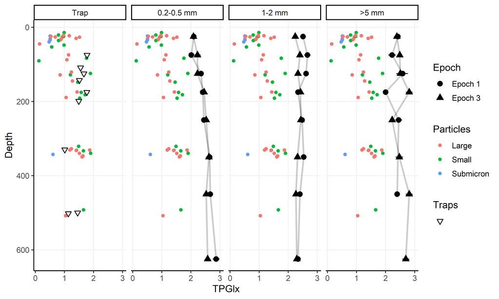

```r
## Plotting TP(Glx-Phe)
plot.parts_zoops.TPGlx =
  ggplot()+
  scale_y_reverse() +
  geom_point(
    data = Data.plots.parts[-which(colnames(Data.plots.parts)=="Size")],
    aes(x = TPGlx, y = Depth,
        xmin = TPGlx-sdTPGlx, xmax = TPGlx+sdTPGlx,
        color = Sizecat),
    position = position_jitterdodge(jitter.height = 10),
    shape = 16, size=1.5, stroke=1)+
  geom_point(
    data = Data.plots.traps,
    aes(x = TPGlx, y = Depth,
        xmin = TPGlx-sdTPGlx, xmax = TPGlx+sdTPGlx,
        size=""),
    color = "black", stroke = 0.75, shape = 6)+
  geom_errorbarh(
    data = Data.plots.zoops,
    aes(x = TPGlx, y = Depth,
        xmin = TPGlx-sdTPGlx, xmax = TPGlx+sdTPGlx),
    height = 1, size = 0.5, linetype = 1, color = 'black')+
  geom_point(
    data = Data.plots.zoops,
    aes(x = TPGlx, y = Depth,
        xmin = TPGlx-sdTPGlx, xmax = TPGlx+sdTPGlx,
        shape = Epoch),
    color = "black", fill="black", stroke = 0.5, size=3)+
  geom_path(
    data = Data.plots.zoops,
    aes(x = TPGlx, y = Depth,
        xmin = TPGlx-sdTPGlx, xmax = TPGlx+sdTPGlx,
        group = interaction(Location,Epoch)),
    color = "black", size = 1, linetype = "solid", alpha = 0.20)+
  facet_wrap(~ Size, nrow=1)+
  labs(color = "Particles", size = "Traps")
   Warning in geom_point(data = Data.plots.parts[-which(colnames(Data.plots.parts)
   == : Ignoring unknown aesthetics: xmin and xmax
   Warning in geom_point(data = Data.plots.traps, aes(x = TPGlx, y = Depth, :
   Ignoring unknown aesthetics: xmin and xmax
   Warning in geom_errorbarh(data = Data.plots.zoops, aes(x = TPGlx, y = Depth, :
   Ignoring unknown aesthetics: x
   Warning in geom_point(data = Data.plots.zoops, aes(x = TPGlx, y = Depth, :
   Ignoring unknown aesthetics: xmin and xmax
   Warning in geom_path(data = Data.plots.zoops, aes(x = TPGlx, y = Depth, :
   Ignoring unknown aesthetics: xmin and xmax

plot.parts_zoops.TPGlx
   Warning: Using size for a discrete variable is not advised.
   Warning: `position_jitterdodge()` requires non-overlapping x intervals.
   `position_jitterdodge()` requires non-overlapping x intervals.
   `position_jitterdodge()` requires non-overlapping x intervals.
   `position_jitterdodge()` requires non-overlapping x intervals.
   Warning: Removed 4 rows containing missing values or values outside the scale range
   (`geom_point()`).
```

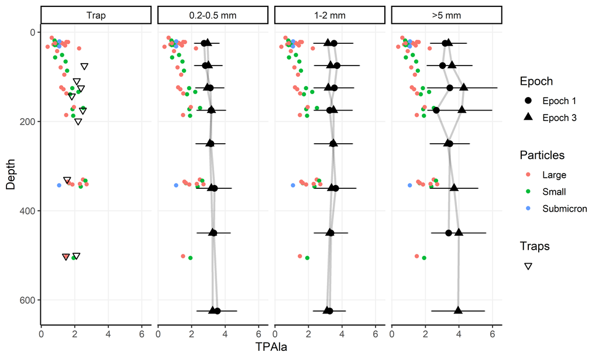

```r
## Plotting TP(Glx-Phe)
plot.parts_zoops.TPAla =
  ggplot()+
  scale_y_reverse() +
  geom_point(
    data = Data.plots.parts[-which(colnames(Data.plots.parts)=="Size")],
    aes(x = TPAla, y = Depth,
        xmin = TPAla-sdTPAla, xmax = TPAla+sdTPAla,
        color = Sizecat),
    position = position_jitterdodge(jitter.height = 10),
    shape = 16, size=1.5, stroke=1)+
  geom_point(
    data = Data.plots.traps,
    aes(x = TPAla, y = Depth,
        xmin = TPAla-sdTPAla, xmax = TPAla+sdTPAla,
        size=""),
    color = "black", stroke = 0.75, shape = 6)+
  geom_errorbarh(
    data = Data.plots.zoops,
    aes(x = TPAla, y = Depth,
        xmin = TPAla-sdTPAla, xmax = TPAla+sdTPAla),
    height = 1, size = 0.5, linetype = 1, color = 'black')+
  geom_point(
    data = Data.plots.zoops,
    aes(x = TPAla, y = Depth,
        xmin = TPAla-sdTPAla, xmax = TPAla+sdTPAla,
        shape = Epoch),
    color = "black", fill="black", stroke = 0.5, size=3)+
  geom_path(
    data = Data.plots.zoops,
    aes(x = TPAla, y = Depth,
        xmin = TPAla-sdTPAla, xmax = TPAla+sdTPAla,
        group = interaction(Location,Epoch)),
    color = "black", size = 1, linetype = "solid", alpha = 0.20)+
  facet_wrap(~ Size, nrow=1)+
  labs(color = "Particles", size = "Traps")
   Warning in geom_point(data = Data.plots.parts[-which(colnames(Data.plots.parts)
   == : Ignoring unknown aesthetics: xmin and xmax
   Warning in geom_point(data = Data.plots.traps, aes(x = TPAla, y = Depth, :
   Ignoring unknown aesthetics: xmin and xmax
   Warning in geom_errorbarh(data = Data.plots.zoops, aes(x = TPAla, y = Depth, :
   Ignoring unknown aesthetics: x
   Warning in geom_point(data = Data.plots.zoops, aes(x = TPAla, y = Depth, :
   Ignoring unknown aesthetics: xmin and xmax
   Warning in geom_path(data = Data.plots.zoops, aes(x = TPAla, y = Depth, :
   Ignoring unknown aesthetics: xmin and xmax

plot.parts_zoops.TPAla
   Warning: Using size for a discrete variable is not advised.
   Warning: `position_jitterdodge()` requires non-overlapping x intervals.
   `position_jitterdodge()` requires non-overlapping x intervals.
   `position_jitterdodge()` requires non-overlapping x intervals.
   `position_jitterdodge()` requires non-overlapping x intervals.
   Warning: Removed 12 rows containing missing values or values outside the scale range
   (`geom_point()`).
```

Zooplankton were consistently TP = 3-4, with little systematic change between epochs. We do notice that >5 mm zooplankton had higher TP in Epoch 3, likely due to the arrival of large hypriid amphipods at that time.